# Statistical Inference Part2 Tooth Growth

rachelxi

27 April 2015

## Loading Data and Basic Analysis

Firstly, we output the names of the data

```r
data(ToothGrowth)
names(ToothGrowth)
```

```
## [1] "len"  "supp" "dose"
```

```r
head(ToothGrowth)
```

```
##    len supp dose
## 1  4.2   VC  0.5
## 2 11.5   VC  0.5
## 3  7.3   VC  0.5
## 4  5.8   VC  0.5
## 5  6.4   VC  0.5
## 6 10.0   VC  0.5
```

And also the size of the data (60 observations, 3 variables)

```r
dim(ToothGrowth)
```

```
## [1] 60  3
```

Also, by looking at the help files, we know the data describes: The response is the length of odontoblasts (teeth) in each of 10 guinea pigs at each of three dose levels of Vitamin C (0.5, 1, and 2 mg) with each of two delivery methods (orange juice or ascorbic acid). Then we can carry exploratory analysis to the data with plot:

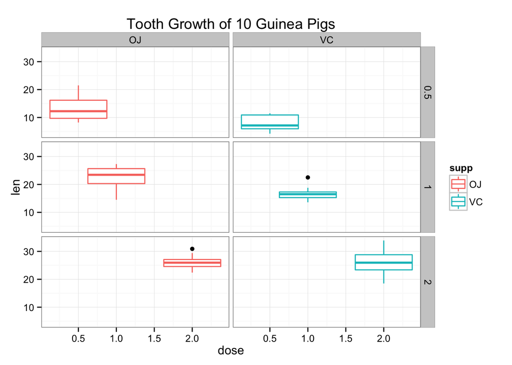

```r
library(ggplot2)
p <- ggplot(ToothGrowth,aes(x=dose,y=len,colour=supp))+geom_boxplot()
p+theme_bw()+facet_grid(dose~supp)+labs(title="Tooth Growth of 10 Guinea Pigs")
```

## Summary of Data

We can perform the summary of data by separating supplement type and dose, calculating the mean, variance and standard deviation respectively:

```r
library(plyr)
ddply(ToothGrowth,.(supp,dose),summarize,mean=mean(len),var=var(len),sd=sd(len))
```

```
##   supp dose  mean       var       sd
## 1   OJ  0.5 13.23 19.889000 4.459709
## 2   OJ  1.0 22.70 15.295556 3.910953
## 3   OJ  2.0 26.06  7.049333 2.655058
## 4   VC  0.5  7.98  7.544000 2.746634
## 5   VC  1.0 16.77  6.326778 2.515309
## 6   VC  2.0 26.14 23.018222 4.797731
```

## Hypothesis Test and Confidence Level (95%)

Before we conduct the t test, it is essetial to process the data first

```r
inter <- split(ToothGrowth,ToothGrowth$dose)
inter2 <- split(ToothGrowth,ToothGrowth$supp)
suppOJ <- inter2[[1]]
suppVC <- inter2[[2]]
```

Then first t test is about length to supplement with dose=0.5mg

```r
t.test(len~supp,data=inter[[1]],paired=FALSE)
```

```
##
##  Welch Two Sample t-test
##
## data:  len by supp
## t = 3.1697, df = 14.969, p-value = 0.006359
## alternative hypothesis: true difference in means is not equal to 0
## 95 percent confidence interval:
##  1.719057 8.780943
## sample estimates:
## mean in group OJ mean in group VC
##            13.23             7.98
```

Then second t test is about length to supplement with dose=1.0mg

```r
t.test(len~supp,data=inter[[2]],paired=FALSE)
```

```
##
##  Welch Two Sample t-test
##
## data:  len by supp
## t = 4.0328, df = 15.358, p-value = 0.001038
## alternative hypothesis: true difference in means is not equal to 0
## 95 percent confidence interval:
##  2.802148 9.057852
## sample estimates:
## mean in group OJ mean in group VC
##            22.70            16.77
```

Then third t test is about length to supplement with dose=2.0mg

```r
t.test(len~supp,data=inter[[3]],paired=FALSE)
```

```
##
##  Welch Two Sample t-test
##
## data:  len by supp
## t = -0.0461, df = 14.04, p-value = 0.9639
## alternative hypothesis: true difference in means is not equal to 0
## 95 percent confidence interval:
##  -3.79807  3.63807
## sample estimates:
## mean in group OJ mean in group VC
##            26.06            26.14
```

The fourth t test is about length to dose with supplement=OJ(orange juice)

```r
t.test(suppOJ$dose,suppOJ$len,paired=FALSE)
```

```
##
##  Welch Two Sample t-test
##
## data:  suppOJ$dose and suppOJ$len
## t = -16.0923, df = 29.535, p-value = 3.699e-16
## alternative hypothesis: true difference in means is not equal to 0
## 95 percent confidence interval:
##  -21.97262 -17.02071
## sample estimates:
## mean of x mean of y
##  1.166667 20.663333
```

The fifth t test is about length to dose with supplement=VC(ascorbic acid)

```r
t.test(suppVC$dose,suppVC$len,paired=FALSE)
```

```
##
##  Welch Two Sample t-test
##
## data:  suppVC$dose and suppVC$len
## t = -10.4365, df = 29.341, p-value = 2.168e-11
## alternative hypothesis: true difference in means is not equal to 0
## 95 percent confidence interval:
##  -18.89076 -12.70257
## sample estimates:
## mean of x mean of y
##  1.166667 16.963333
```

## Assumptions and Conclusions

The t tests are using default settings because I assume there is no paired relations between the tested data; confidence interval is calculated with “two.sided” method; the variances of two are assumed to be non-equal.